# Clustering - Deriv CRP

We are interested in clustering clients based on their trading behavior in the stock market. By analyzing their trading frequency, volume, profit, and other relevant features, we aim to identify groups of clients with similar trading patterns and behaviors. This information can be extremely valuable for financial institutions, as it can help them to better understand the needs and preferences of their clients, identify potential risks and opportunities, and tailor their investment strategies and services accordingly.

```python
df_trades = pd.read_csv('Trading Clients.csv')
```

## Preprocessing

### Feature engineering

To deal with the high skewness of some features, we applied a log transformation to normalize the data and improve the performance of the clustering algorithms. Additionally, we label-encoded the trading_day_of_week variable to represent the days of the week as integers from 0 to 6.

Overall, feature engineering allowed us to extract valuable information from the raw trading data and create informative features that could capture the underlying patterns and relationships in the data. By using these features in the clustering analysis, We were able to identify groups of clients with similar trading behaviors and preferences, and gain insights into the characteristics and needs of each group.

```python
def extract_features(data):
  # Create features based on data
  data['price_per_volume'] = data['price'] / data['volume']
  data['num_trades'] = data.groupby('login')['login'].transform('count')

  #Aggregate data data
  agg_operations = {
    'action': 'mean',
    'price': 'mean',
    'volume': 'mean',
    'price_stop_loss': 'mean',
    'rate_profit': 'mean',
    'tick_value': 'mean',
    'profit_raw': 'mean',
    'price_per_volume': 'mean',
    'num_trades': 'size'
  }

  df_new = data.groupby('login').agg(agg_operations)

  # Design more features from df_new
  df_new['total_profit'] = data.groupby('login')['profit'].sum()
  df_new['average_profit_per_trade'] = df_new['total_profit'] / data.groupby('login')['deal'].nunique()
  df_new['trading_frequency'] = data.groupby('login')['deal'].nunique()
  df_new['trading_hour'] = pd.to_datetime(data['time_deal']).dt.hour.groupby(data['login']).agg(lambda x:x.value_counts().index[0])
  df_new['trading_day_of_week'] = pd.to_datetime(data['time_deal']).dt.day_name().groupby(data['login']).agg(lambda x:x.value_counts().index[0])
  df_new['trading_style'] = pd.get_dummies(data['action']).groupby(data['login']).sum().idxmax(axis=1)


  # Label encode 'trading_day_of_week'
  from sklearn.preprocessing import LabelEncoder
  df_new['trading_day_of_week'] = LabelEncoder().fit_transform(df_new['trading_day_of_week'])
  return df_new

df_new = extract_features(df_trades)
```

### Normalizing

```python
def normalize(dataframe):

  # Calculate the skewness of each feature
  skewness = dataframe.skew()

  # Filter for features with absolute skewness greater than 2.5
  high_skew_features = skewness[abs(skewness) > 2.5].index

  # Apply log1p transformation to scale the high-skew features
  dataframe[high_skew_features] = dataframe[high_skew_features].apply(lambda x: np.log(x) if x.min() > 0 else np.log(x - x.min() + 1))

  # Scale the data
  from sklearn.preprocessing import StandardScaler
  scaler = StandardScaler()
  dataframe= scaler.fit_transform(dataframe)

  return dataframe

df_new = normalize(df_new)
```

### Dimensionality reduction

UMAP (Uniform Manifold Approximation and Projection) is a nonlinear dimensionality reduction technique that is particularly useful for high-dimensional data visualization and clustering. Unlike traditional linear techniques such as PCA, UMAP can preserve complex geometric structures in the data and can capture both global and local structure. This makes it particularly useful for finding clusters and visualizing high-dimensional datasets. In the context of your data, UMAP allowed us to reduce the 15-dimensional dataset to only 2 dimensions, making it easier to cluster and visualize the data. As you will see, the visualization shows clear clusters after we apply the pre-processing we've done so far.

MAP is more advanced than K-means in the sense that it can handle high-dimensional data and preserve the local structure of the data while reducing its dimensionality. UMAP is also more flexible than K-means since it can be used for both visualization and clustering.

```python
!pip install umap-learn
import umap.umap_ as umap
```

```python
# Apply UMAP to the encoded data to reduce the dimensionality to 2
umap_2d = umap.UMAP(n_components=2, random_state=42)
umap_data = umap_2d.fit_transform(df_new)

#Add the reduced data to the original dataframe
umap_1 = umap_data[:,0]
umap_2 = umap_data[:,1]
```

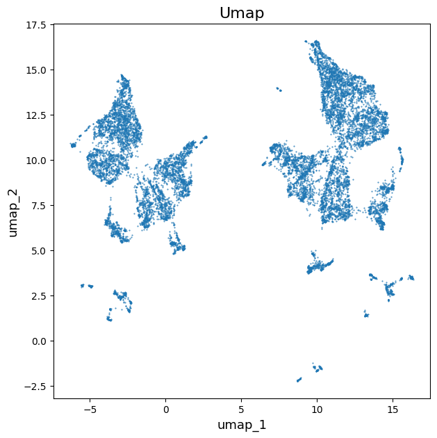

```python
plt.figure(figsize = (7,7))

plt.scatter(umap_1, umap_2,
            cmap="viridis",
            s = 0.2)

plt.title("Umap", fontsize = 16)
plt.xlabel("umap_1",fontsize = 13)
plt.ylabel("umap_2",fontsize = 13)
plt.show()
```

## Modeling

Agglomerative clustering is a hierarchical clustering technique that works by iteratively merging small clusters into larger ones until all data points belong to a single cluster. In other words, it starts with each data point in its own cluster and then successively merges them into larger clusters based on a distance metric until a stopping criterion is met. One of the main advantages of agglomerative clustering is its ability to discover clusters of different sizes and shapes, as well as nested clusters. This makes it a powerful technique for exploring the underlying structure of complex datasets. Additionally, agglomerative clustering can be used with different distance metrics and linkage methods, allowing for flexible customization based on the characteristics of the data.

```python
from sklearn.cluster import AgglomerativeClustering

param = {'n_clusters':4,
        'affinity': 'euclidean',
        'linkage': 'ward'}

clustering = AgglomerativeClustering(**param).fit(umap_data)
labels = clustering.labels_
```

- Silhouette Score

$$s(i)=\dfrac{b(i)-a(i)}{max(a(i),b(i))}$$

The formula for the silhouette score $s(i)$ for a single point $i$ contains two important terms:

$a(i)$: the mean distance between $i$ and all other points in its own cluster.

$b(i)$: the distance between $i$ and its next nearest cluster centroid.

Towards the positive extreme of $s(i) = 1$, we must have that $b(i) \gg a(i)$, so the point $i$ is either sat right on top of all of the other points in its cluster ($a(i)=0$) or the nearest cluster is infinitely far away ($b(i) \rightarrow \infty$). Therefore, $s(i)=1$ represents good quality clustering.

Moving towards the negative extreme of $s(i)=-1$, we now must have that $a(i) \gg b(i)$, so point $i$ is either sat right on top of all of the points in its nearest neighbour cluster ($b(i)=0$), or all of the other points in its own assigned cluster are infinitely far away ($a(i) \rightarrow \infty$). In the latter case, point $i$ most likely should have been assigned to its nearest neighbour, therefore, $s(i)=-1$ represents poor quality clustering.

```python
from sklearn.metrics import silhouette_score
silhouette_avg = silhouette_score(umap_data, labels)
print("Silhouette Score: {:.4f}".format(silhouette_avg))
```

```
Silhouette Score: 0.4612
```

- Label visualization

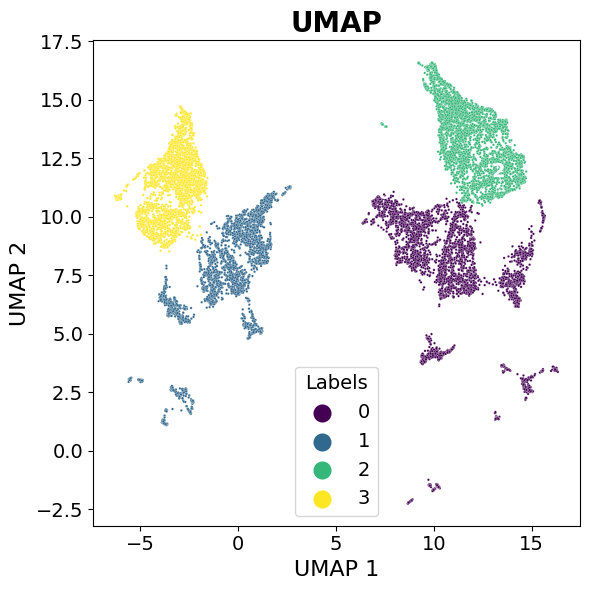

```python
import numpy as np
import matplotlib.pyplot as plt
import seaborn as sns

# Calculate the center of mass for each cluster
centers = []
for label in np.unique(labels):
    center = np.mean(np.array([umap_2[labels == label], umap_1[labels == label]]), axis=1)
    centers.append(center)

plt.figure(figsize=(6, 6))
sns.scatterplot(x=umap_1, y=umap_2, hue=labels, palette="viridis", s=3)

# Add labels at the center of mass of each cluster
for label, center in enumerate(centers):
    plt.annotate(label, xy=center, fontsize=14, fontweight='bold', color='white',
                 ha='center', va='center')

plt.title("UMAP", fontsize=20, fontweight='bold')
plt.xlabel("UMAP 1", fontsize=16)
plt.ylabel("UMAP 2", fontsize=16)
plt.tick_params(labelsize=14)
plt.legend(fontsize=14, title="Labels", title_fontsize=14, loc='best', markerscale=2)

plt.tight_layout()
plt.savefig('umap.png')
plt.show()
```

We hope it's clear now why we've decided to use UMAP :) There are well formed clusters, but we must validate them somehow, so here is the next step.

### Validation by modeling

One way to validate the clusters we've found using a clustering algorithm is to train a neural network on the clustered data and evaluate its performance. Here's a simple approach we'll follow:

1. Split the data into training and validation sets.
2. Train a neural network on the training set, where the input is the feature vector of each data point and the output is the cluster label. We will use a simple multi-layer perceptron (MLP).
3. Once the neural network is trained, evaluate its performance on the validation set. We can use metrics such as accuracy, precision, recall, and F1 score to evaluate how well the neural network is able to classify the data points into the clusters.
4. If the neural network achieves high accuracy on the validation set, it can be an indication that the clusters you found using the clustering algorithm are valid. On the other hand, if the neural network performs poorly, it may indicate that the clustering algorithm did not find meaningful clusters.
- Train, test, val split

```python
X,y = df_new, labels
```

```python
from sklearn.model_selection import train_test_split

X_train, X_test, y_train, y_test = train_test_split(X, y, test_size=0.25, random_state=42)
X_train, X_val, y_train, y_val = train_test_split(X_train, y_train, test_size=0.2, random_state=42)
```

- Create model

```python
from sklearn.metrics import accuracy_score, f1_score
from keras.models import Sequential
from keras.layers import Dense

model = Sequential()
model.add(Dense(64, activation='relu', input_dim=X_train.shape[1]))
model.add(Dense(32, activation='relu'))
model.add(Dense(4, activation='softmax')) # We have four clusters, therefor we must predict 4 clusters

model.compile(optimizer='adam', loss='sparse_categorical_crossentropy', metrics=['accuracy'])
```

- Train the model

```python
history = model.fit(X_train, y_train, epochs=50, batch_size=32, validation_data=(X_val, y_val))
```

- Evaluate the model

```python
# Evaluate on validation set
val_preds = model.predict(X_val)
val_preds = np.argmax(val_preds, axis=1)
val_acc = accuracy_score(y_val, val_preds)
val_f1 = f1_score(y_val, val_preds, average='weighted')

# Evaluate on test set
test_preds = model.predict(X_test)
test_preds = np.argmax(test_preds, axis=1)
test_acc = accuracy_score(y_test, test_preds)
test_f1 = f1_score(y_test, test_preds, average='weighted')

print(f'Validation accuracy: {val_acc:.4f}')
print(f'Validation F1 score: {val_f1:.4f}')
print(f'Test accuracy: {test_acc:.4f}')
print(f'Test F1 score: {test_f1:.4f}')
```

```
Validation accuracy: 0.9897
Validation F1 score: 0.9897
Test accuracy: 0.9915
Test F1 score: 0.9915
```

These scores reflect the performance of the neural network model in validating the clusters that were obtained through the clustering algorithm.

The high validation and test accuracy and F1 scores suggest that the neural network was able to accurately classify the data points into their respective clusters. A high accuracy indicates that a high percentage of the data points were correctly classified, while a high F1 score indicates a good balance between precision and recall. This means that the clusters we found are well separated and represent meaningful groupings of the data.

## Interpreting clusters

- Getting the original data

```python
df_feat_extrac = extract_features(df_trades)
df = normalize(df_feat_extrac)
```

```python
cols =['action', 'price', 'volume', 'price_stop_loss', 'rate_profit',
       'tick_value', 'profit_raw', 'price_per_volume', 'num_trades',
       'total_profit', 'average_profit_per_trade', 'trading_frequency',
       'trading_hour', 'trading_day_of_week', 'trading_style']

df = pd.DataFrame(df, columns =  cols)
df['cluster'] = labels
```

- **Analysis**

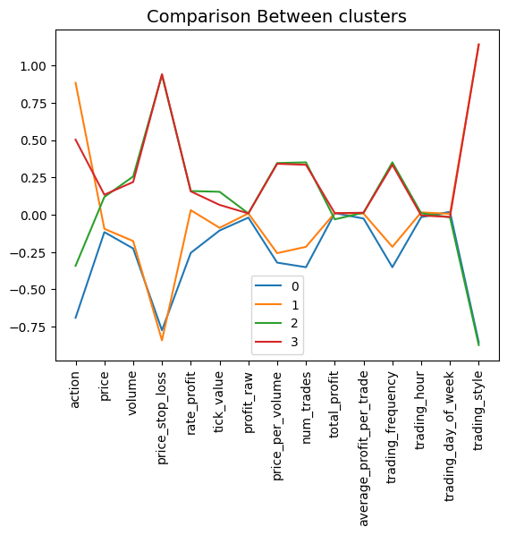

```python
for i in range(4):

  data = df[df['cluster'] == i].drop('cluster',axis = 1)
  mean = data.mean()
  plt.plot(mean,label = i)

plt.legend([0,1,2,3])

plt.title('Comparison Between clusters',fontsize = 14)
plt.xticks(rotation = 90)
plt.show()
```

As we can see, the 'profit_raw', 'total_profit', 'average_profit_per_trade', 'trading_day_of_week','trading_hour' columns don't really differ the groups, so let's drop them for now.

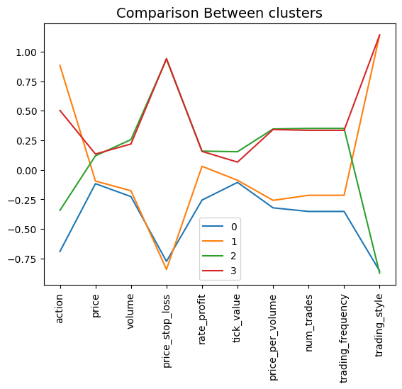

```python
df2 = df.drop(['profit_raw', 'total_profit', 'average_profit_per_trade','trading_hour', 'trading_day_of_week'],axis = 1)

for i in range(4):

  data = df2[df2['cluster'] == i].drop('cluster',axis = 1)
  mean = data.mean()
  plt.plot(mean,label = i)

plt.legend([0,1,2,3])

plt.title('Comparison Between clusters',fontsize = 14)
plt.xticks(rotation = 90)
plt.show()
```

Right now we can see some interesting things:

Clusters 0 and 1 are very similar to each, with exception of trading style and action (which are very similar features), and clusters 2 and 3 are also very similar (but again with exception of trading style and action.

Let's take a look again at the UMAP data we got earlier.

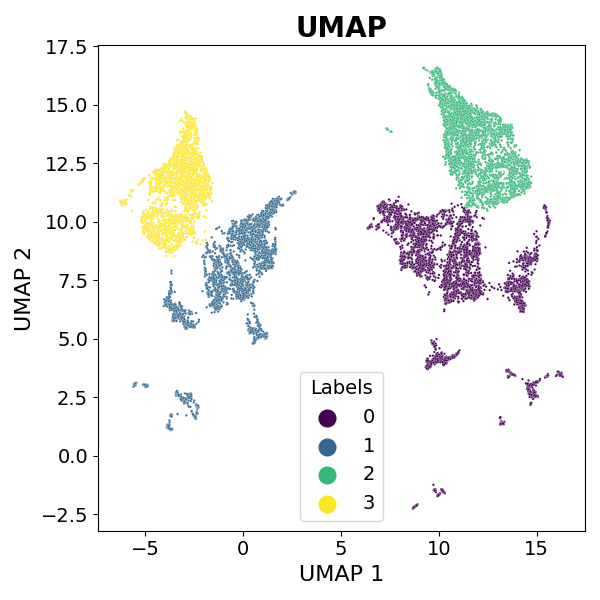

Notice clusters 0 and 1 seem to be a reflection of each other. Both have a 'stripe' of emptiness in their middle, both got possible outliers and tails. Overall they are the same, but reflected. This is merely due to the fact that clusters 0 and 1 are very similar to each other with exception at trading style.

The same exact thing happens with clusters 2 and 3.

(To be honest, I have never seen this pattern emerge from UMAP. This is perhaps the most beautiful thing I have ever seen)

### Clusters names and their interpretations

Now that we've got an overall understanding of our clients, we can give them some names and what they represent.

**"The Chillaxers" (Cluster 0):** This group seems to have a more laid-back approach to trading. They take fewer actions, have lower trading frequency, and generally trade with lower volumes and values. They also have a lower rate of profit, suggesting they may be less focused on maximizing gains and more focused on minimizing losses.

**"The Daredevils" (Cluster 1):** In contrast to Cluster 0, these traders seem to be more willing to take risks and make bold moves. They have a very high action rate, suggesting they are quick to make decisions, and they also have a high trading style value, which may indicate a preference for more aggressive trading strategies, although maintaing a low profile, with lower profits and number of trades.

**"The Strategists" (Cluster 2):** This group seems to take a more thoughtful and methodical approach to trading. They have high prices, volumes, and values, suggesting they may be trading more substantial assets. They also have high rates of profit, which may indicate a focus on long-term gains rather than quick wins.